# Traffic Data Analysis

Ahmed Akram

```r
library(dplyr)
library(ggplot2)
library(knitr)
library(stringr)
library(class)
```

### Data Processing

We’ll load the data and take a look around its different columns and a sample of records.

```r
Sys.setlocale(category="LC_ALL", locale="en_US.UTF-8")
```

```
## [1] "en_US.UTF-8/en_US.UTF-8/en_US.UTF-8/C/en_US.UTF-8/C"
```

```r
data.raw <- read.csv('traffic-data.csv', encoding="UTF-8")
data.raw %>% glimpse
```

```
## Observations: 429,982
## Variables: 34
## $ crawl_date      (fctr) Fri Feb  5 17:23:57 UTC 2016, Fri Feb  5 17:2...
## $ ad.aid          (int) 2538, 2538, 2538, 2538, 2538, 2538, 2538, 2538...
## $ ad.bgcl         (fctr) #003768, #003768, #003768, #003768, #003768, ...
## $ ad.bgcls        (fctr) #0069aa, #0069aa, #0069aa, #0069aa, #0069aa, ...
## $ ad.fncl         (fctr) #FFFFFF, #FFFFFF, #FFFFFF, #FFFFFF, #FFFFFF, ...
## $ ad.fncls        (fctr) #FFFFFF, #FFFFFF, #FFFFFF, #FFFFFF, #FFFFFF, ...
## $ ad.lid          (int) 1001, 1001, 1001, 1001, 1001, 1001, 1001, 1001...
## $ ad.logo         (fctr) http://www.bey2ollak.com/downloads/logos/Peps...
## $ ad.logo2x       (fctr) http://www.bey2ollak.com/downloads/logos/Peps...
## $ ad.logoAndroidS (fctr) http://www.bey2ollak.com/downloads/logos/Peps...
## $ ad.logoAndroidH (fctr) http://www.bey2ollak.com/downloads/logos/Peps...
## $ ad.cm           (fctr) دوس هنا وشوف إعلان بيبسي الجديد مع محمد صلاح ...
## $ ad.url          (fctr) http://youtu.be/aNeqShdgupY, http://youtu.be/...
```

[output cut: 21 more lines]

#### removing constant features

we have many features concerning the ads, let’s see how many unique ad logos we got, just to make sure the ad features are not relevant to our investigation.

```r
data.raw %>% select(ad.logo) %>% unique %>% nrow
```

```
## [1] 1
```

since there’s only one unique logo, then the ad is the same across all the rerports we got. Let’s remove all features prefixed with “ad”

```r
data.reports <- data.raw %>% select(-(starts_with("ad")))
```

let’s run this and get the count of unique elements for each feature

```r
count_uniques <- sapply(data.reports, function(x) length(unique(x)))
```

now remove those with a 1 unique element

```r
unwanted <- count_uniques[count_uniques == 1]
data.reports <- data.reports[, !names(data.reports) %in% names(unwanted)]
```

#### Investigating duplicates

let’s try to find if we got any duplicates. A duplicate would occur if we crawled the same data, but at different times. So first I’ll ignore the “crawl_date” column and compare using the rest.

```r
data.no_date <- data.reports %>% select(-(crawl_date))
```

get all unique reports based only on the comment id, since each comment has a unique id (I suppose .. ?)

```r
data.unique_comments_ids <- data.no_date %>% subset(!duplicated(rd.rp.cmid))
data.unique_comments_ids %>% nrow
```

```
## [1] 148367
```

now when I remove all the times features, we already removed the crawl date, but there are those columns telling us when the reprot was posted (posted 2 hours ago), this one will be represented by `rd.rp.hr` and `rd.rp.mn`. Morever there’re `rd.hr` and `rd.mn`. I’m still not quite sure what they represent, but most probably the last time the whole line or road was updated.

I’ll remove all those for now and have the data with no times at all.

```r
data.no_times <- data.no_date %>% select(-rd.hr, -rd.mn, -rd.rp.hr, -rd.rp.mn)
```

Now if I were to run this, I expect to have the same number of records that I had in the `data.unique_comments_ids` dataframe.

```r
data.no_times %>% unique %>% nrow
```

```
## [1] 209375
```

as you can see that doesn’t happen, the later gave us `148367` while this one `209375`. I need to know which records are there with the same comment ids but differ in other columns. Let’s investigate this a bit.

```r
data.raw %>% count(rd.rp.cmid) %>% subset(n > 1) %>% arrange(-n)
```

```
## Source: local data frame [143,033 x 2]
##
##    rd.rp.cmid     n
##         (int) (int)
## 1     9303358     4
## 2     9303481     4
## 3     9303488     4
## 4     9303579     4
## 5     9303742     4
## 6     9305789     4
## 7     9305799     4
## 8     9305800     4
## 9     9305802     4
## 10    9305809     4
## ..        ...   ...
```

grouping the data by the `cmid` and looking at them, shows that each group has a maximum of 4 comments grouped together. The below function just prints some of these groups.

```r
fn <- function(data) {
    cm_ids <- data %>% count(rd.rp.cmid) %>% subset(n > 1) %>% arrange(-n) %>% select(rd.rp.cmid)
    cm_ids_arr <- cm_ids$rd.rp.cmid
    for(i in 1:5)
        print(data %>% subset(rd.rp.cmid == cm_ids_arr[i]) %>% select(rd.rp.cm, rd.rp.nm, rd.nm, rd.stid), width=Inf)
}
```

let’s execute it:

```r
fn(data.no_times %>% unique)
```

```
##             rd.rp.cm rd.rp.nm                 rd.nm rd.stid
## 211846 clear till 75  El_Bedo Sa7rawy;Alex To Cairo      10
## 211873 clear till 75  El_Bedo Sa7rawy;Alex To Cairo       6
## 398183 clear till 75  El_Bedo Sa7rawy;Alex To Cairo      10
## 398218 clear till 75  El_Bedo Sa7rawy;Alex To Cairo       6
##             rd.rp.cm       rd.rp.nm                 rd.nm rd.stid
## 211845 clear till 67 mahmoudayyad91 Sa7rawy;Alex To Cairo      10
## 211872 clear till 67 mahmoudayyad91 Sa7rawy;Alex To Cairo       6
## 398182 clear till 67 mahmoudayyad91 Sa7rawy;Alex To Cairo      10
## 398217 clear till 67 mahmoudayyad91 Sa7rawy;Alex To Cairo       6
##                          rd.rp.cm       rd.rp.nm                 rd.nm
## 211844 @El_Bedo  any further news mahmoudayyad91 Sa7rawy;Alex To Cairo
## 211871 @El_Bedo  any further news mahmoudayyad91 Sa7rawy;Alex To Cairo
## 398181 @El_Bedo  any further news mahmoudayyad91 Sa7rawy;Alex To Cairo
## 398216 @El_Bedo  any further news mahmoudayyad91 Sa7rawy;Alex To Cairo
##        rd.stid
## 211844      10
## 211871       6
## 398181      10
## 398216       6
##                 rd.rp.cm       rd.rp.nm                 rd.nm rd.stid
## 211843 clear lel bawabat mahmoudayyad91 Sa7rawy;Alex To Cairo      10
## 211870 clear lel bawabat mahmoudayyad91 Sa7rawy;Alex To Cairo       6
## 398180 clear lel bawabat mahmoudayyad91 Sa7rawy;Alex To Cairo      10
## 398215 clear lel bawabat mahmoudayyad91 Sa7rawy;Alex To Cairo       6
##              rd.rp.cm         rd.rp.nm                 rd.nm rd.stid
## 211842 Clear till 120 hesh_salama_2020 Sa7rawy;Alex To Cairo      10
## 211869 Clear till 120 hesh_salama_2020 Sa7rawy;Alex To Cairo       6
## 398179 Clear till 120 hesh_salama_2020 Sa7rawy;Alex To Cairo      10
## 398214 Clear till 120 hesh_salama_2020 Sa7rawy;Alex To Cairo       6
```

## Removing duplicates

```r
data.unique <- data.reports %>% subset(!duplicated(rd.rp.cmid))
```

#### Reformating crawl_date

Format the crawl_date into date and adding 2 hours to accomodate for difference in timing between Cairo time and UTC time.

```r
data.unique$crawl_date <- strptime(data.unique$crawl_date, "%a %b %d %H:%M:%S UTC %Y", tz="UTC")

data.unique$crawl_date <- data.unique$crawl_date + as.difftime(2, unit="hours")
```

#### Getting the real time of the report

Now to get the actual date of the report, we need to use the `rd.rp.hr` and `rd.rp.mn` columns. These two form the `1 hour ago`, `30 mins ago` and so on. So by performing crawl_hour - rd.rp.hr we should get the actual hour of posting the report.

```r
data.unique$report_times <- (data.unique$crawl_date - as.difftime(as.numeric(data.unique$rd.rp.hr), unit="hours") - as.difftime(as.numeric(data.unique$rd.rp.mn), unit="mins"))

data.unique$report_hour <- data.unique$report_times %>% format("%H")
data.unique$report_minute <- data.unique$report_times %>% format("%M")
data.unique$report_day_name <- data.unique$report_times %>% format("%a")
```

#### Renaming the features

| rd.rp.cmid | rerport.id |
| --- | --- |
| rd.rp.cm | report_comment |
| rd.rp.stid | report_status |
| rd.rp.nm | reporter_name |
| rd.rp.fullnm | reporter_full_name |
| rd.ri | road_id |
| rd.stid | road_status |
| rd.nm | road_name |

```r
data.unique <- data.unique %>% rename(
    report_comment=rd.rp.cm,
    report_status_id=rd.rp.stid,
    report_id=rd.rp.cmid,
    reporter_name=rd.rp.nm,
    reporter_full_name=rd.rp.fullnm,
    road_id=rd.ri,
    road_status_id=rd.stid,
    road_name=rd.nm
)

data.unique <- data.unique %>% select(-rd.rp.hr, -rd.rp.mn, -rd.hr, -rd.mn)
```

```r
cat(sort(data.unique%>%names()), sep="\n")
```

```
## crawl_date
## rd.cmrq
## rd.img
## rd.new
## rd.rp.img
## rd.rp.rpImg
## rd.strq
## report_comment
## report_day_name
## report_hour
## report_id
## report_minute
## report_status_id
## report_times
## reporter_full_name
## reporter_name
## road_id
## road_name
## road_status_id
```

#### Identifying different statuses [lazeez, 7alawa …]

by running this for each report_status, we can get the most frequent associated comment.

```r
status <- function() {
  ret = c()
  for(id in 1:11) {
    status_word <- (data.unique %>% subset(report_status_id == id) %>% count(report_comment) %>% arrange(-n))[1,1]

    ret[id] = c(status_word, id)
  }
  ret
}

status()
```

```
## [[1]]
## [1] 7alawa
## 44716 Levels: , fe radarat ? ,10 min to moneebl ,400 ,57 radar ... ييجي منه حلاوة بس risky شوية.
##
## [[2]]
## [1] lazeez
## 44716 Levels: , fe radarat ? ,10 min to moneebl ,400 ,57 radar ... ييجي منه حلاوة بس risky شوية.
##
## [[3]]
## [1] mashy
## 44716 Levels: , fe radarat ? ,10 min to moneebl ,400 ,57 radar ... ييجي منه حلاوة بس risky شوية.
##
## [[4]]
## [1] za7ma
## 44716 Levels: , fe radarat ? ,10 min to moneebl ,400 ,57 radar ... ييجي منه حلاوة بس risky شوية.
##
## [[5]]
## [1] mafeesh amal
## 44716 Levels: , fe radarat ? ,10 min to moneebl ,400 ,57 radar ... ييجي منه حلاوة بس risky شوية.
##
## [[6]]
## [1] Eih el nezam?
## 44716 Levels: , fe radarat ? ,10 min to moneebl ,400 ,57 radar ... ييجي منه حلاوة بس risky شوية.
##
## [[7]]
## [1] khatar-radar
## 44716 Levels: , fe radarat ? ,10 min to moneebl ,400 ,57 radar ... ييجي منه حلاوة بس risky شوية.
##
## [[8]]
## [1] 7adsa
## 44716 Levels: , fe radarat ? ,10 min to moneebl ,400 ,57 radar ... ييجي منه حلاوة بس risky شوية.
##
## [[9]]
## [1] 3otl
## 44716 Levels: , fe radarat ? ,10 min to moneebl ,400 ,57 radar ... ييجي منه حلاوة بس risky شوية.
##
## [[10]]
## [1] overall 3 mins
## 44716 Levels: , fe radarat ? ,10 min to moneebl ,400 ,57 radar ... ييجي منه حلاوة بس risky شوية.
##
## [[11]]
## [1] <NA>
## 44716 Levels: , fe radarat ? ,10 min to moneebl ,400 ,57 radar ... ييجي منه حلاوة بس risky شوية.
```

| 1 | 7alawa |
| --- | --- |
| 2 | lazeez |
| 3 | mashy |
| 4 | za7ma |
| 5 | mafeesh amal |
| 6 | Eigh el nezam? |
| 7 | khatar-radar |
| 8 | 7adsa |
| 9 | 3otl |
| 10 | GPS reporter status |

```r
data.unique$report_hour <- as.numeric(data.unique$report_hour)

data.unique$report_status <-
  data.unique$report_status_id %>%
  sapply(function(x) {
    statuses <- c("7alawa", "lazeez", "mashy", "za7ma", "mafeesh amal", "Eigh el nezam?", "khatar-radar", "7adsa", "3otl", "GPS reporter status")

     statuses[x]
})
```

### Data Analysis

LEt’s start by plotting some graphs ( finally :’) ), we’ll plot the hour of day against the no. of reports

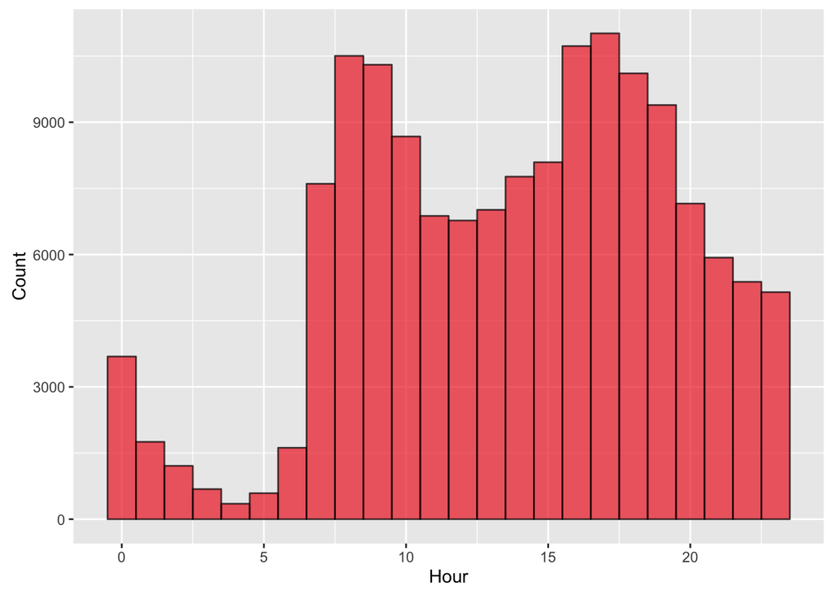

```r
p <- data.unique %>% ggplot() + stat_count(aes(x=report_hour, show_legend=FALSE), fill="firebrick2", colour="black" ,alpha=0.7, width=1) + xlab("Hour") + ylab("Count")

p
```

the results agrees with kind of an obvious insight that the rush hours would have the most number of reports. (8-10 AM and 4-6 PM)

Now let’s plot the no. of reports against the report status

```r
png(file="statuses.png",width=400, height=350)
p <- data.unique %>% ggplot() + stat_count(aes(x=report_status, show_legend=FALSE, geom="point"), fill="blue", colour="cyan", alpha=0.7, width=0.96) + xlab("Hour") + ylab("Count")
dev.off()
```

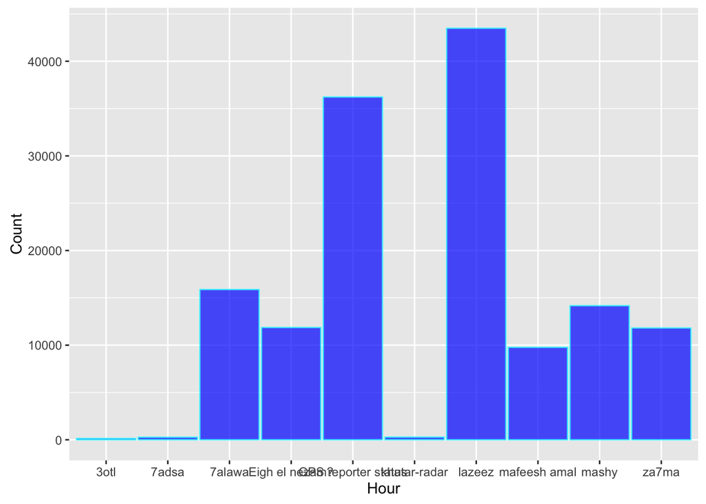

```r
p
```

this is really interesting, what I had in mind (and kinda makes sense) is that the negative report would be more thatn the positive, because supposedly I’ll open the app and broadcast the status when I’m bored and stuck in traffic. However, as we can see it’s totally the opposite. I still feel that something ain’t right regarding that and will need more investigation. So let’s dive in …

## investigate the positive vs negative reports

let’s group by status and hour, and then add a new feature counting how many reports in each hour and status

```r
data.grouped <- data.unique %>% group_by_("report_status", "report_hour") %>% mutate(reports_per_hour_and_status=n())
```

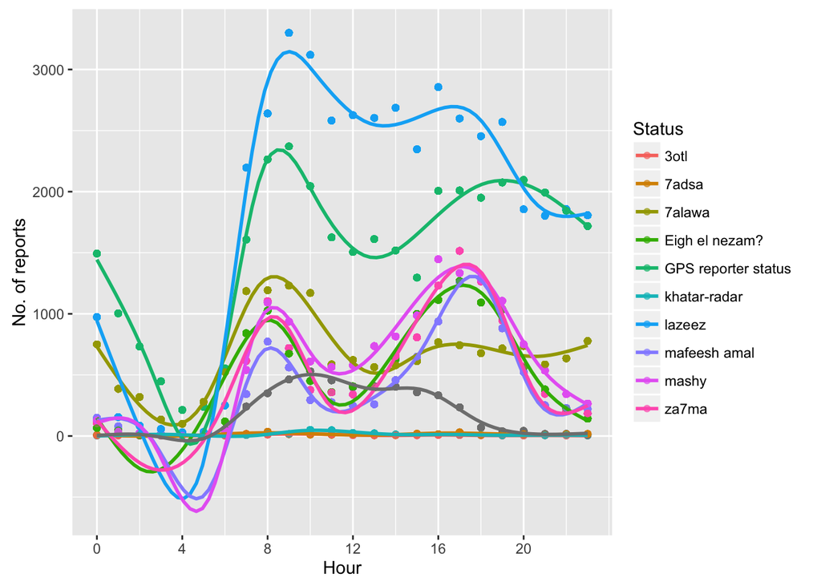

```r
p <- data.grouped %>% ggplot(aes(report_hour, reports_per_hour_and_status, col=report_status)) + scale_x_continuous(name="Hour", breaks=seq(0,23, 4)) + scale_y_continuous("No. of reports") + scale_color_discrete("Status")

p.scatter <- p + geom_point(alpha=0.6)

p.scatter.smooth <- p.scatter + geom_smooth(se=FALSE, span=0.1)

p.scatter.smooth
```

Let’s extract the speed from bey2ollak’s gps auto reporter

```r
data.unique$speed <- data.unique %>% select(report_comment) %>% apply(1, function(x) {
    speed1 <- str_extract(x, "[0-9]+ km") %>% str_extract("[0-9]+") %>% as.numeric()

    if(is.na(speed1)[1]) {
        speed2 <- str_extract(x, "[0-9]+ كم") %>% str_extract("[0-9]+") %>% as.numeric()
        speed_result <- speed2
    }else {
        speed_result <- speed1
    }

    speed_result
})
```

a quick summary of the speeds

```r
data.unique$speed %>% summary
```

```
##    Min. 1st Qu.  Median    Mean 3rd Qu.    Max.    NA's
##     0.0    43.0    62.0    62.2    79.0  1519.0   89941
```

we need to remove the outliers

```r
data.unique %>% subset(speed > 200) %>% select(report_comment)
```

```
##                                                                                       report_comment
## 104841         ana ma3ako 3l tare2 ana nw fadely 210 km 3l 3'arda2a I'll feed you back by the update
## 158649 From [Dar El Salam Exit] to [Kornish Ma3ady Exit] took [1 mins] with average speed [273 km/h]
## 167925                                                                    clear till 389 km to Cairo
## 168929                                                                  radar around 399 km to Cairo
## 169323                                      clear till 382 km to cairo to sokhna: all clear no radar
## 274483                        From [Ta7rir] to [Zamalek] took [1 mins] with average speed [294 km/h]
## 315637                                       من [زمالك] إلى [تحرير] في [1 ق] ومتوسط سرعته [427 كم/س]
## 316123           From [Batal Ahmed St.] to [Agouza St.] took [1 mins] with average speed [1519 km/h]
## 316528                        From [Zamalek] to [Ta7rir] took [1 mins] with average speed [466 km/h]
## 318496                        From [Zamalek] to [Ta7rir] took [1 mins] with average speed [445 km/h]
## 395616                                 من [التجمع] إلى [ستاد الجيش] في [1 ق] ومتوسط سرعته [207 كم/س]
```

(shabab mostahter ….)

```r
data.unique <- data.unique %>% subset(speed <= 200)
```

Let’s see how many repors have a status of “GPS reporter status”

```r
gps = "bey2ollakgps"
data.unique %>% subset(report_status_id == 10) %>% subset(reporter_name==gps) %>% nrow
```

```
## [1] 34485
```

and the following will get how many reports by bey2ollak gps have meaningful statuses [lazeez, 7alawa, za7ma …]

```r
 data.unique %>% subset(!is.na(report_status)) %>% subset(report_status_id != 10) %>% subset(reporter_name==gps) %>% select(report_comment, speed, report_status) %>% nrow
```

```
## [1] 23803
```

we need to classify those with status “GPS Report” into one of the other categories. First, let’s boxplot the speed against the statuses. I guess we’ll find a lot of outliers in the “GPS reporter status” as it contains a lot of repots that need to be categorized

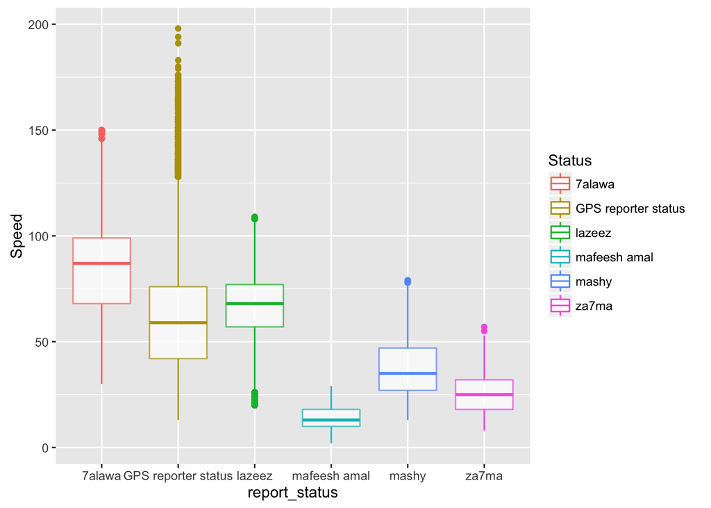

```r
data.unique %>% subset(report_status != "khatar-radar") %>% subset(!is.na(speed)) %>% subset(reporter_name==gps) %>% subset(!is.na(report_status)) %>% ggplot(aes(report_status, speed, col=report_status)) + geom_boxplot(alpha=0.7) +  scale_y_continuous("Speed") + scale_color_discrete("Status")
```

as expected we do have a lot of outliers. The “lazeez” status has some outliers into the negative part too. This could be explained by the fact that there’re some roads that are not suitable for high speeds, but they’re actually moving and not stuck, e.g. a car running 20 km/hr not because of the traffic, but rather because the road is not well done.